# Capstone Vignette

Muhammad Ezzat

3/27/2020

# Inroduction

This vinette is dedicated to explain functions from my Capstone Project of the Coursera Specialization : Mastering Software development with R.Without any further to say, let’s try out our functions.

## Cleaning Data

### eq_location_clean

This function takes the location name as an argument & cleans it out by removing the country’s name and adjusting the location name.

```r
clean_labels <- eq_location_clean(data$LOCATION_NAME)
print(head(clean_labels))
```

```
## [1] "  BAB-A-DARAA,AL-KARAK"     "  UGARIT"
## [3] "  W"                        "  THERA ISLAND (SANTORINI)"
## [5] "  ARIHA (JERICHO)"          "  LACUS CIMINI"
```

### eq_clean_data

This function cleans the whole data set, it adjusts the location name, removes usless columns & changes longtiude & latitude columns to numeric columns. It also removes missing values on comand by setting na.rm argument to TRUE.

```r
Fclean_data <- eq_clean_data(data)
Tclean_data <- eq_clean_data(data,T)
print(head(Fclean_data))
```

```
## # A tibble: 6 x 13
##     I_D DATE        YEAR MONTH   DAY EQ_PRIMARY LATITUDE LONGITUDE
##   <dbl> <date>     <dbl> <dbl> <dbl>      <dbl>    <dbl>     <dbl>
## 1     1 2150-01-01 -2150     1     1        7.3     31.1      35.5
## 2     2 2000-01-01 -2000     1     1       NA       35.7      35.8
## 3     3 2000-01-01 -2000     1     1        7.1     38        58.2
## 4  5877 1610-01-01 -1610     1     1       NA       36.4      25.4
## 5     8 1566-01-01 -1566     1     1       NA       31.5      35.3
## 6    11 1450-01-01 -1450     1     1       NA       35.5      25.5
## # ... with 5 more variables: LOCATION_NAME <chr>, COUNTRY <chr>,
## #   STATE <chr>, TOTAL_DEATHS <dbl>, TIME <chr>
```

```r
print(head(Tclean_data))
```

```
## # A tibble: 6 x 13
##     I_D DATE        YEAR MONTH   DAY EQ_PRIMARY LATITUDE LONGITUDE
##   <dbl> <date>     <dbl> <dbl> <dbl>      <dbl>    <dbl>     <dbl>
## 1  1609 1812-12-08  1812    12     8        6.9     34.4    -118.
## 2  1610 1812-12-21  1812    12    21        7.5     34.2    -120.
## 3  2120 1867-11-18  1867    11    18        7.5     18.1     -65.1
## 4  2125 1868-04-03  1868     4     3        7.9     19      -156.
## 5  2148 1868-10-21  1868    10    21        6.8     37.7    -122.
## 6  2195 1872-03-26  1872     3    26        7.8     36.7    -118.
## # ... with 5 more variables: LOCATION_NAME <chr>, COUNTRY <chr>,
## #   STATE <chr>, TOTAL_DEATHS <dbl>, TIME <chr>
```

## Visualizing Data I

After we’re done with Module 1, Module 2 required two geoms, geom_timeline() & geom_timeline_label(). Let’s watch them in action.

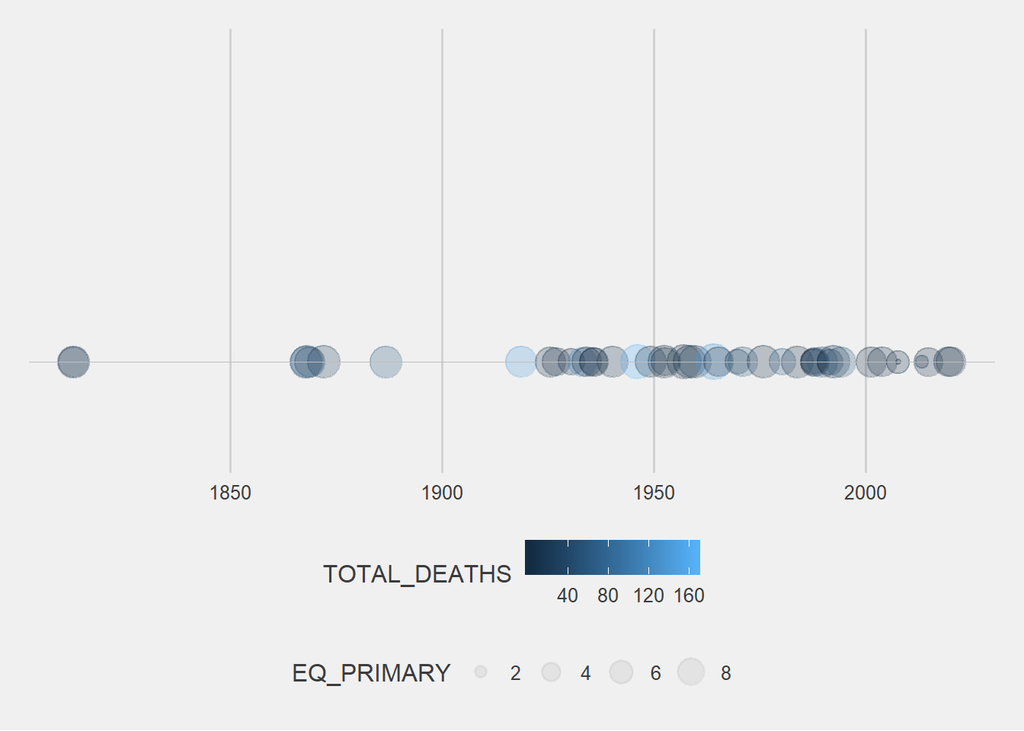

```r
gObj <- ggplot(Tclean_data,aes(x=DATE))+theme_fivethirtyeight()
gObj + geom_timeline(aes(size = EQ_PRIMARY, col=TOTAL_DEATHS))
```

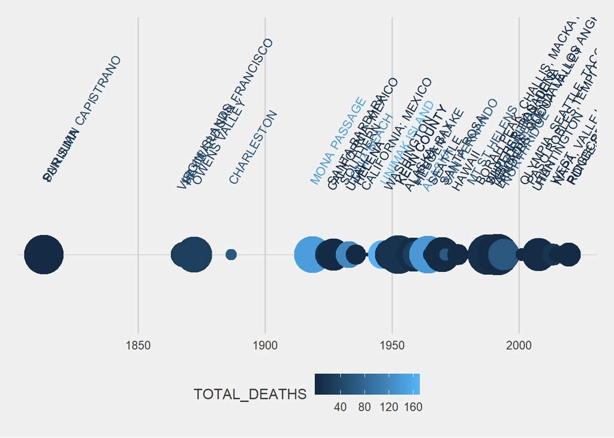

```r
gObj + geom_timeline_label(aes(magnitude = EQ_PRIMARY, label=LOCATION_NAME, col = TOTAL_DEATHS))
```

Unfortunately geom_timeline_label() isn’t doing it’s best, but it’s under improvment.

## Visualizing Data II

The third module was about using leaflet interactive maps, we had to functions, one creates an HTML label consists of many elemnts, the other was to plot. We can use them as follow

```r
dplyr::mutate(Tclean_data,label = eq_create_label(Tclean_data))
```

| I_D | DATE | YEAR | MONTH | DAY | EQ_PRIMARY | LATITUDE | LONGITUDE | LOCATION_NAME | COUNTRY | STATE | TOTAL_DEATHS | TIME | label |
| --- | --- | --- | --- | --- | --- | --- | --- | --- | --- | --- | --- | --- | --- |
| 1609 | 1812-12-08 | 1812 | 12 | 8 | 6.9 | 34.370 | -117.650 | SAN JUAN CAPISTRANO | USA | CA | 40 | AD | Location: SAN JUAN CAPISTRANOMagnitude:6.9Total deaths:40 |
| 1610 | 1812-12-21 | 1812 | 12 | 21 | 7.5 | 34.200 | -119.900 | PURISIMA | USA | CA | 1 | AD | Location: PURISIMAMagnitude:7.5Total deaths:1 |
| 2120 | 1867-11-18 | 1867 | 11 | 18 | 7.5 | 18.100 | -65.100 | VIRGIN ISLANDS | USA TERRITORY | VI | 24 | AD | Location:VIRGIN ISLANDSMagnitude:7.5Total deaths:24 |
| 2125 | 1868-04-03 | 1868 | 4 | 3 | 7.9 | 19.000 | -155.500 | SE OF | USA | HI | 77 | AD | Location: SE OFMagnitude:7.9Total deaths:77 |
| 2148 | 1868-10-21 | 1868 | 10 | 21 | 6.8 | 37.700 | -122.100 | HAYWARD,SAN FRANCISCO | USA | CA | 30 | AD | Location: HAYWARD,SAN FRANCISCOMagnitude:6.8Total deaths:30 |
| 2195 | 1872-03-26 | 1872 | 3 | 26 | 7.8 | 36.700 | -118.100 | OWENS VALLEY | USA | CA | 27 | AD | Location: OWENS VALLEYMagnitude:7.8Total deaths:27 |
| 2362 | 1886-09-01 | 1886 | 9 | 1 | 7.3 | 32.900 | -80.000 | CHARLESTON | USA | SC | 60 | AD | Location: CHARLESTONMagnitude:7.3Total deaths:60 |
| 3124 | 1918-10-11 | 1918 | 10 | 11 | 7.1 | 18.700 | -67.189 | MONA PASSAGE | USA TERRITORY | PR | 144 | AD | Location: MONA PASSAGEMagnitude:7.1Total deaths:144 |
| 3270 | 1925-06-29 | 1925 | 6 | 29 | 6.8 | 34.418 | -120.196 | SANTA BARBARA | USA | CA | 13 | AD | Location: SANTA BARBARAMagnitude:6.8Total deaths:13 |
| 3305 | 1927-01-01 | 1927 | 1 | 1 | 5.8 | 32.500 | -115.500 | CALIFORNIA, MEXICO | USA | CA | 1 | AD | Location:CALIFORNIA, MEXICOMagnitude:5.8Total deaths:1 |

[output cut: 35 more lines]

```r
eq_map(Tclean_data,'label')
```

[interactive chart not shown]

One little warning that it won’t appear on a pdf vinette, it requires an HTML one.

That was my submission hope you rate it good, thank you.